# Reproducible Research: Peer Assessment 1

## Imputing missing values

1. The number of missing rows can be found with the summary function. ANSWER: NA’s = 2304

```r
summary(stepdata)
```

```
##      steps                date          interval
##  Min.   :  0.00   2012-10-01:  288   Min.   :   0.0
##  1st Qu.:  0.00   2012-10-02:  288   1st Qu.: 588.8
##  Median :  0.00   2012-10-03:  288   Median :1177.5
##  Mean   : 37.38   2012-10-04:  288   Mean   :1177.5
##  3rd Qu.: 12.00   2012-10-05:  288   3rd Qu.:1766.2
##  Max.   :806.00   2012-10-06:  288   Max.   :2355.0
##  NA's   :2304     (Other)   :15840
```

2. Strategy to replace missing values: Replace every missing NA with the average for that interval 3a. Make a copy “stepdata2” of the original “stepdata” dataframe. 3b. Use a loop to test every ‘steps’ value for NA and if true, replace it with the average value for that interval

```r
stepdata2 <- stepdata
for(i in 1:length(stepdata2$interval)) {
    if(is.na(stepdata2[i, "steps"])) {
        stepdata2[i,"steps"] <- steps_per_5m[steps_per_5m$interval == stepdata2[i,"interval"],"steps"]
    }
}
```

```r
steps_per_day2 <- aggregate(stepdata2$steps, list(stepdata2$date), sum, na.rm = TRUE)
names(steps_per_day2) <- c("date","steps")
head(steps_per_day2)
```

```
##         date    steps
## 1 2012-10-01 10766.19
## 2 2012-10-02   126.00
## 3 2012-10-03 11352.00
## 4 2012-10-04 12116.00
## 5 2012-10-05 13294.00
## 6 2012-10-06 15420.00
```

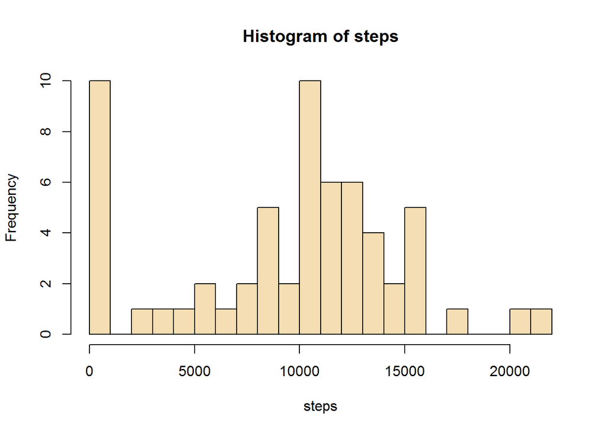

```r
with (steps_per_day, hist(steps, breaks = 20, col = "wheat"))
```

```r
summary(steps_per_day2$steps)
```

```
##    Min. 1st Qu.  Median    Mean 3rd Qu.    Max.
##      41    9819   10770   10770   12810   21190
```

```r
dev.copy(png, file = "./figures/steps_by_day.png")
```

```r
dev.off
```

[output not shown]

## Are there differences in activity patterns between weekdays and weekends?

```r
weekday <- weekdays(as.Date(stepdata2$date))
for(i in 1:length(weekday)) {
    if(weekday[i] == weekdays(as.Date("2016-01-02"))) {weekday[i] <- "weekend"}
    else if(weekday[i] == weekdays(as.Date("2016-01-02"))) {weekday[i] <- "weekend"}
    else {weekday[i] <- "weekday"}
}
stepdata3 <- cbind(stepdata2, weekday)
```

2a. Create a new variable ‘avg_steps_5m_weekday’ that averages the steps over two factors: ‘ínterval’ and ‘weekday’ 2b. Add names to the variables 2c. Create an emtpty plot of steps versus interval of avg_steps_5m_weekday 2d. Plot the points where factor ‘weekday’ equals ‘weekend’ in red 2e. Plot the points where factor ‘weekday’ equals ‘weekday’ in blue 2f. Plot a legend 2g. Copy the plot to a png file

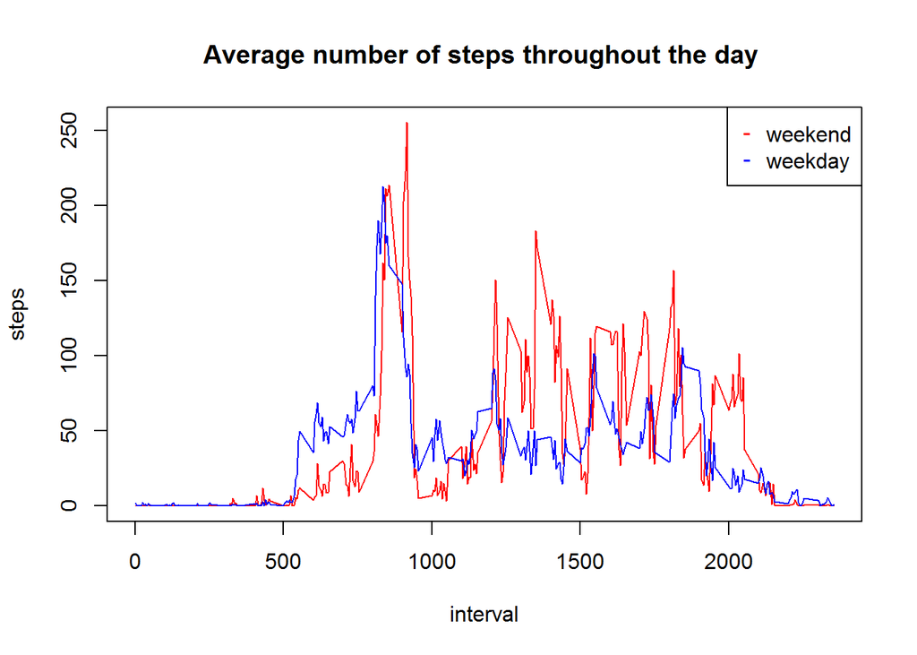

```r
avg_steps_5m_weekday <- aggregate(stepdata3$steps, list(stepdata3$interval, stepdata3$weekday), mean)
names(avg_steps_5m_weekday) <- c("interval", "weekday", "steps")
with(avg_steps_5m_weekday, plot(interval, steps, type = "n", main = "Average number of steps throughout the day "))
with(avg_steps_5m_weekday, points(interval[weekday == "weekend"], steps[weekday == "weekend"], type = "l", col = "red"))
with(avg_steps_5m_weekday, points(interval[weekday == "weekday"], steps[weekday == "weekday"], type = "l", col = "blue"))
legend("topright", pch = "-", col = c("red", "blue"), legend = c("weekend", "weekday"))
```

```r
dev.copy(png, file = "./figures/steps_throughout_day.png")
```

```r
dev.off
```

[output not shown]